# COVID-19 Impact: Dagahaley Refugee Camp

The Potential Impact of COVID-19 in the Dagahaley Refugee Camp

Shaun Truelove, Natalya Kostandova, Andrew Azman

## Summary

### Purpose

To explore the potential impact of SARS-CoV-2 virus on refugees in Dagahaley camp to help decision makers develop plan appropriately.

### Methods

We used a scenario-based approach to model transmission in this population after an introduction of the virus. Assuming a stable population, and a single introduction of the virus into the camp, using three different sets of assumptions about the transmission potential of SARS-CoV-2 at this site, we estimated the number of infections, hospitalizations, deaths, and health care needs that might be expected.

### Results

We found that even in a low transmission scenario, a large-scale outbreak was highly likely after a single introduction of the virus into the camp, with 60% of the simulations leading to an outbreak of at least 100 infections and increasing to 79% and 92% in moderate and high transmission scenarios, respectively. On average, in the first 30 days of an outbreak following a single introduction, we expect 111 (95% CI, 102 - 126), 163 (95% CI, 102 - 363), and 674 (95% CI, 111 - 2755) infections in the low, moderate, and high transmission scenarios, respectively. These reach 143676 (95% CI, 124129 – 156492), 178442 (95% CI, 164099 – 188348), and 197090 (95% CI, 193944 – 198734), infections in 12 months, respectively.

## Methods

### Severity estimates

The proportion of infections that result in severe disease was estimated using data from a closed population of contacts of confirmed COVID-19 cases in Shenzhen, China, for which complete data on contact, age, test results, symptoms, and severity were available (Bi et al. 2020). Using a Bayesian binomial model, we estimated the proportion of infections that were severe by 10-year age groups and then applied those estimates to the 10-year age proportions of the camp population to get an overall proportion of infections that will develop into severe disease in the specific population, as a function of age. These estimates do not account for differences in comorbidities, differing attack rates by age due to population mixing characteristics, or various other factors that may be important in this setting.

### Transmission scenarios

One of the primary drivers of our epidemic simulations is the transmission potential characterized by the basic reproductive number ($R_0$), or the average number of people each infected individual is expected to transmit to assuming no immunity. We considered three potential scenarios with different values of $R_0$: 1) a low transmission scenario based on transmission levels in many of the Chinese provinces with elevated isolation and control practices and an $R_0$ similar to influenza ($R_0=1.5-2.0$); 2) a moderate transmission scenario that mirrors estimates in early stages of the outbreak in Wuhan, China ($R_0=2.0-3.0$); and, 3) a high transmission scenario where we assume that $R_0$ is increased by a factor of 1.65 ($R_0=3.3-5.0$) compared to estimates from open community settings, as was observed during the 2017 diphtheria outbreak. The $R_0$ in each of these scenarios falls within the 95% confidence interval of the current range of estimates for COVID-19$^{28}$. We assumed an Erlang distributed serial interval (time between the onset of symptoms in infector-infectee pairs) with a mean of 6 days (standard deviation = 4.2), and used a stochastic SEIR model to simulate transmission in this population.

### Hospitalization and mortality

We assume that in this setting hospitalization would be limited to those with severe disease (defined as tachypnea ($\ge$ 30 breaths/ min) or oxygen saturation ≤93% at rest, or PaO2/FIO2 <300, and/or lung infiltrates >50% of the lung field within 24-48 hours), and not used as a means of isolation. Thus, we assumed the hospitalization rate was equivalent to the severe disease rate. Using estimates based on data from Shenzhen, China, we estimated an age-adjusted rate of severe disease, accounting for the age distribution of Dagahaley, and applied this severe disease rate to incident infections from the model simulations. We estimated deaths assuming a 10% case fatality risk rate among hospitalizations/severe disease. We assumed hospitalization occurs a median of 3.42 days after symptom onset (lognormally distributed, sd=0.79), hospitalized cases are discharged after a mean of 11.5 days (95% CI, 8.0-17.3), and deaths occur after a mean of 11.2 days (95% CI, 8.7-14.9). Additionally, early reports from the outbreak in China indicate that mechanical ventilation was required by approximately 25% of patients with severe disease, while the remaining 75% required only oxygen supplementation.

## Results

### Infections

We found that a large-scale outbreak is highly likely in this population, even under the low transmission scenario, with 60% of the simulations producing an outbreak of at least 100 infections with a single introduction (Table 1) and increasing to 79% and 92% in the moderate and high transmission scenarios, respectively. On average, in the first 30 days of an outbreak following a single introduction, we expect 111 (95% CI, 102 - 126), 163 (95% CI, 102 - 363), and 674 (95% CI, 111 - 2755) infections in the low, moderate, and high transmission scenarios, respectively. One year after the start of an outbreak, and in the absence of any effective interventions (e.g., vaccination, quarantine) or behavior change, we expect 72% (95% CI, 62 - 78%) of the population to have been infected under the low scenario, 89% (95% CI, 82 - 94%) in the moderate scenario, and 99% (95% CI, 97 - 99%) in the high transmission scenario (Table 1).

By the time the first hospitalization occurs, we expect 63 (95% CI, 1 - 233) individuals to be infected in the population under the low scenario, assuming homogeneous probability of infection by age. This increases to 102 (95% CI, 2 - 399) and 233 (95% CI, 5 - 920) in the moderate and high scenarios, respectively. When the first hospitalization occurs, we expect the virus to have been circulating in this population for an average of 43, 34, and 25 days under the low, moderate, and high transmission scenarios, respectively.

### Table 1

Overall impact of simulated outbreaks in Dagahaley, assuming no effective novel interventions or behavior change. Total infections, hospitalizations, and deaths represent the final cumulative counts after the simulated outbreak ran its full course. Maximum daily counts are the maximum incident counts of infection and hospitalization on a single day across the full outbreak, occurring at the outbreaks peak. We estimated daily capacity need assuming hospitalized individuals remain hospitalized for a mean of 11.5 days (95% CI, 8.0-17.3)$^{25}$, and from the daily capacity needed over time, estimated the maximum capacity needed on any single day, and how many days after the first successful introduction into the expansion site at which hospitalization capacity needs exceeds the existing surge capacity of 200 beds.

| Transmission Scenario | Probability of outbreak of >100 infections after a single introduction | Total Infections,* mean (95% CI) | Total Hospitalizations,* mean (95% CI) | Total Deaths,* mean (95% CI) | Maximum Daily Incident Infections,* mean (95% CI) | Maximum Daily Incident Hospitalizations,* mean (95% CI) | Maximum Daily Hospitalization Capacity Needed (in beds),* mean (95% CI) | Day on which Hospitalization Need Exceeds Capacity,*† mean (95% CI) |
| --- | --- | --- | --- | --- | --- | --- | --- | --- |
| Low $(R_0=1.5-2.0)$ | 0.5976 | 143676 (124129-156492) | 4725 (3886-5646) | 473 (381-574) | 2496 (1644-3187) | 204 (118-338) | 1034 (640-1524) | 74 (45-127) |
| Moderate $(R_0 = 2.0 - 3.0)$ | 0.7872 | 178442 (164099-188348) | 5877 (4858-7129) | 588 (477-720) | 5277 (3709-6701) | 395 (225-681) | 2046 (1286-3066) | 49 (31-82) |
| High $(R_0 = 3.0 - 5.0)$ | 0.9239 | 197090 (193944-198734) | 6490 (5163-8036) | 649 (508-810) | 9837 (8188-11069) | 663 (386-1142) | 3426 (2342-4830) | 31 (20-51) |

* Among simulations with successful introductions that result in outbreaks.  
† Current hospitalization surge capacity estimated to be 200 beds.

### Table 2

Cumulative infections, hospitalizations, intensive care unit (ICU) admissions, patients requiring ventilation, and deaths at 1, 3, and 6 months following successful introduction (i.e. in simulations where an outbreak occurs).

| Transmission Scenario | 1 month Infections, mean (95% CI) | 1 month Hospitalizations, mean (95% CI) | 1 month ICU, mean (95% CI) | 1 month Ventilation, mean (95% CI) | 1 month Deaths, mean (95% CI) | 3 months Infections, mean (95% CI) | 3 months Hospitalizations, mean (95% CI) | 3 months ICU, mean (95% CI) | 3 months Ventilation, mean (95% CI) | 3 months Deaths, mean (95% CI) | 6 months Infections, mean (95% CI) | 6 months Hospitalizations, mean (95% CI) | 6 months ICU, mean (95% CI) | 6 months Ventilation, mean (95% CI) | 6 months Deaths, mean (95% CI) |
| --- | --- | --- | --- | --- | --- | --- | --- | --- | --- | --- | --- | --- | --- | --- | --- |
| Low, $(R_0=1.5-2.0)$ | 111 (102-126) | 2 (0-3) | 0 (0-0) | 0 (0-0) | 0 (0-0) | 1794 (131-8100) | 41 (2-184) | 3 (0-14) | 0 (0-1) | 2 (0-9) | 95602 (4949-153208) | 2928 (130-5249) | 551 (13-1276) | 56 (0-169) | 239 (6-508) |
| Moderate $(R_0 = 2.0 - 3.0)$ | 163 (102-363) | 3 (0-7) | 0 (0-1) | 0 (0-0) | 0 (0-1) | 52459 (689-157448) | 1252 (14-4681) | 65 (0-353) | 2 (0-11) | 48 (0-243) | 176992 (158109-188293) | 5813 (4666-7103) | 1503 (1032-1881) | 217 (101-288) | 575 (429-717) |
| High $(R_0 = 3.0 - 5.0)$ | 674 (111-2755) | 7 (0-28) | 0 (0-1) | 0 (0-0) | 0 (0-1) | 190471 (144489-198590) | 6104 (3446-7925) | 1184 (77-1948) | 79 (0-226) | 529 (83-770) | 195077 (193829-198020) | 6380 (5123-7668) | 1681 (1340-2019) | 253 (197-318) | 637 (495-787) |

### Figure 1

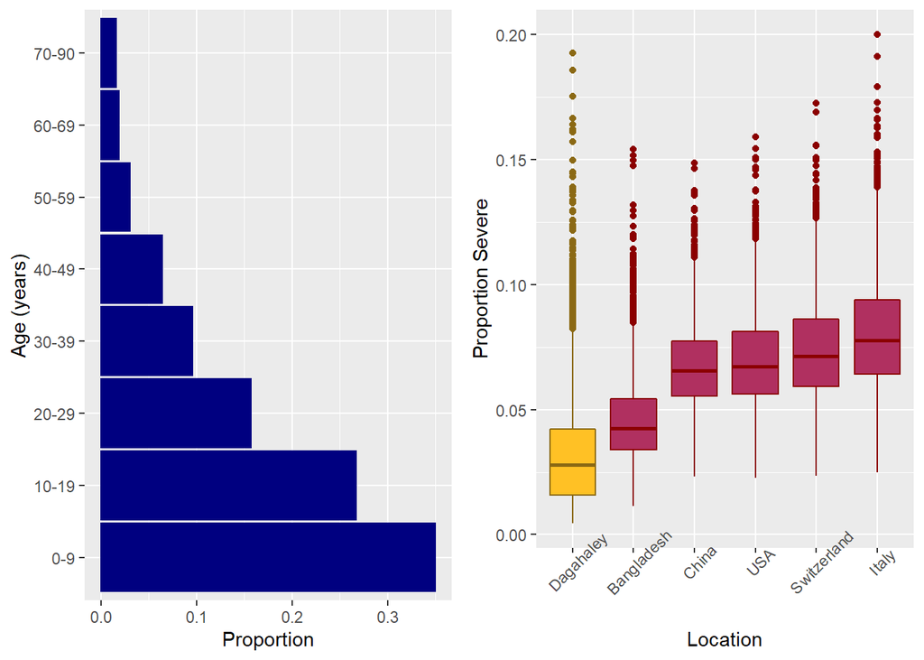

### Figure 2

[figure not shown]

### Figure 3

Hospitalization capacity requirements for an outbreak of SARS-CoV-2 in the Dagahaley camp, under three transmission scenarios: low transmission ($R_0 =1.5-2.0$), moderate transmission ($R_0=2.0-3.0$), and high transmission ($R_0=3.3-5.0$). Dashed red line represents surge capacity for beds.

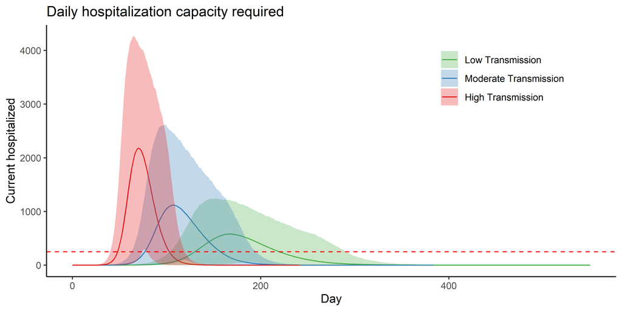